# Supplementary information 6 mRNA microarray analysis for MM vs healthy samples from GSE47552

TFM: Drug repurposing for multiple myeloma using SAveRUNNER in R Máster en Bioinformática y Bioestadística UoC y UB

Sergio Carracedo Huroz

# 1 Abstract

En este informe se muestran genes diferencialmente expresados en muestras de pacientes con mieloma múltiple, así como los correspondientes procesos biológicos enrriquecidos.

# 2 Materials and Methods

## 2.1 Software

El análisis bioinformático presentado en este informe esta basado en el lenguaje R (R version 4.0.3 (2020-10-10)) y el uso de RStudio como interfaz de usuario, donde se han usado los siguientes paquetes tanto del repositorio `CRAN` como del repositorio de `Bioconductor`:

```r
library(knitr)
library(colorspace)
library(gplots)
library(ggplot2)
library(ggrepel)
library(htmlTable)
library(prettydoc)
library(devtools)
library(BiocManager)
library(Biobase)
library(affy)
library(oligo)
library(oligoClasses)
library(pd.mogene.2.1.st)
library(arrayQualityMetrics)
library(pvca)
library(limma)
library(genefilter)
library(hugene10sttranscriptcluster.db)
library(annotate)
library(org.Mm.eg.db)
library(ReactomePA)
library(reactome.db)
library(AnnotationDbi)
```

## 2.2 Data and study design

En cuanto al tipo de estudio, el análisis aquí presentado puede clasificarse como un **estudio comparativo** (*Class comparison*), ya que se comparan muestras de pacientes sanos ó con mieloma múltiple.

En lo que respecta al **diseño experimental**, miramos los siguientes puntos:

- **Fuentes de variabilidad**: Quizás la obtención de muestras pudiera haber sido algo hetereogénea entre muestras, lo que podría introducir variabilidad en los resultados, pero el hecho de tener réplicas biológicas podría minimizar su impacto. Si a partir de aquí las muestras se obtienen o procesan de manera homogénea (en paralelo o con un bloqueo adecuado), la variabilidad no debida a las diferentes condiciones se pueda minimizar. Valoraremos si las fechas de ejecución de los microarrasys dan lugar a un `batch factor` que pueda influenciar los resultados del análisis.
- No se han empleado **réplicas técnicas**.
- **Réplicas biológicas**: Cinco de pacientes sanos y 41 con mieloma múltiple.
- **Aleatorización**: No procede en este caso al estar comparando.

## 2.3 Methods

El pipeline seguido para el análisis mostrado en este informe es análogo al usado en el informe *[Case_Study_1-Microarrays_Analysis.html](https://github.com/ASPteaching/Omics_Data_Analysis-Case_Study_1-Microarrays)* que se puede encontrar en github:

1. Creación de directorios de trabajo y almacenamiento de datos así como creación de la tabla targets.csv con información sobre las diferentes muestras (phenoData).
2. Lectura y visualización de archivos .CEL (datos) del estudio.
3. Normalización y visualización de datos normalizados.
4. *Batch detection*.
5. Detección de genes con mayor variación.
6. Filtraje de genes con menor variación.
7. Generación de matriz de diseño y matriz de contraste.
8. Estimación del modelo para selección de genes diferencialmente expresados.
9. Anotación de genes diferencialmente expresados.
10. Selección y visualización de genes diferencialmente expresados: Diagramas Venn y Heatmaps.
11. Análisis de significación biológica de los resultados.
12. Conclusión.

# 3 Results

## 3.1 Preparation of working directories and folders to store data

Establecemos primeramente nuestro directorio de trabajo

```r
setwd(dirname(rstudioapi::getSourceEditorContext()$path))
```

Dentro del directorio de trabajo generamos los directorios ‘data’ y ‘results’

```r
dir.create("data") # almacenamiento de datos y archivo target.csv
dir.create("results") # almacenamiento de resultados
```

## 3.2 Reading .CEL files and quality control of raw data

Una vez creados los directorios pertinentes y descargados los archivos .CEL en la carpeta `data`, se crea la lista con los archivos .CEL y se prepara el archivo targets.csv (phenodata) en la carpeta `data` de manera que contenga las variables (columnas) Group y Shortname y como nombres los respectivos nombres de los archivos .CEL:

```r
celFiles <- list.celfiles("./data", full.names = TRUE)

# Creamos tabla 'targets':
FileName <-as.character(gsub('./data/','', celFiles)) # Names of files
Group <- as.character(c(rep('MM',41),rep('NPC',5))) # MM or NPC
ShortName <- gsub('.*_','',FileName)
ShortName <- as.character(gsub('.CEL','',ShortName))
targets <- data.frame(FileName,Group,ShortName)

# Guardamos archivo como .txt (HAY QUE ELIMINAR LAS COMILLAS!!):
write.table(targets, file = "./data/targets.txt",row.names = F,sep='\t',quote = FALSE)
```

Cada fila corresponderá a un archivo .CEL del estudio como se puede ver en la siguiente tabla:

```r
targets <- read.csv2("./data/targets.txt", header = TRUE, sep = "\t")
knitr::kable( targets, booktabs = TRUE,
              caption = 'Contenido del archivo targets.csv usado en este análisis.')
```

Table 3.1: Contenido del archivo targets.csv usado en este análisis.

| FileName | Group | ShortName |
| --- | --- | --- |
| GSM1152309_M687.CEL | MM | M687 |
| GSM1152310_M724.CEL | MM | M724 |
| GSM1152311_M758.CEL | MM | M758 |
| GSM1152312_M786.CEL | MM | M786 |
| GSM1152313_M797.CEL | MM | M797 |
| GSM1152314_M801.CEL | MM | M801 |
| GSM1152315_M813.CEL | MM | M813 |
| GSM1152316_M828.CEL | MM | M828 |
| GSM1152317_M832.CEL | MM | M832 |
| GSM1152318_M833.CEL | MM | M833 |
| GSM1152319_M856.CEL | MM | M856 |
| GSM1152320_M880.CEL | MM | M880 |
| GSM1152321_M896.CEL | MM | M896 |
| GSM1152322_M906.CEL | MM | M906 |
| GSM1152323_M942.CEL | MM | M942 |
| GSM1152324_M956.CEL | MM | M956 |
| GSM1152325_M988.CEL | MM | M988 |
| GSM1152326_M995.CEL | MM | M995 |
| GSM1152327_M1017.CEL | MM | M1017 |
| GSM1152328_M1018.CEL | MM | M1018 |
| GSM1152329_M1028.CEL | MM | M1028 |
| GSM1152330_M1037.CEL | MM | M1037 |
| GSM1152331_M1041.CEL | MM | M1041 |
| GSM1152332_M1042.CEL | MM | M1042 |
| GSM1152333_M1049.CEL | MM | M1049 |
| GSM1152334_M1051.CEL | MM | M1051 |
| GSM1152335_M1054.CEL | MM | M1054 |
| GSM1152336_M1062.CEL | MM | M1062 |
| GSM1152337_M1070.CEL | MM | M1070 |
| GSM1152338_M1081.CEL | MM | M1081 |
| GSM1152339_M1089.CEL | MM | M1089 |
| GSM1152340_M1093.CEL | MM | M1093 |
| GSM1152341_M1094.CEL | MM | M1094 |
| GSM1152342_M1105.CEL | MM | M1105 |
| GSM1152343_M1111.CEL | MM | M1111 |
| GSM1152344_M1117.CEL | MM | M1117 |
| GSM1152345_M1134.CEL | MM | M1134 |
| GSM1152346_M1137.CEL | MM | M1137 |
| GSM1152347_M1142.CEL | MM | M1142 |
| GSM1152348_M1148.CEL | MM | M1148 |
| GSM1152349_M1155.CEL | MM | M1155 |
| GSM1152350_N1351.CEL | NPC | N1351 |
| GSM1152351_N1362.CEL | NPC | N1362 |
| GSM1152352_N1588.CEL | NPC | N1588 |
| GSM1152353_N1610.CEL | NPC | N1610 |
| GSM1152354_N1645.CEL | NPC | N1645 |

```r
library(oligo)
library(Biobase)

my.targets <-read.AnnotatedDataFrame(file.path("./data","targets.txt"),
                                     header = TRUE, row.names = 1,
                                     sep="\t")

rawData <- read.celfiles(celFiles, phenoData = my.targets)
```

Para evaluar la calidad de los datos crudos que tenemos en este estudio le aplicamos a dichos datos la función `arrayQualityMetrics()` del paquete con el mismo nombre:

```r
library(arrayQualityMetrics)
arrayQualityMetrics(rawData,force=T)
dev.off()
```

A partir del análisis anterior se obtiene una carpeta con diferentes gráficos diagnósticos para cada muestra (heatmaps, boxplots y MA plots), los cuales se muestran resumidos en la tabla que se muestra a continuación:

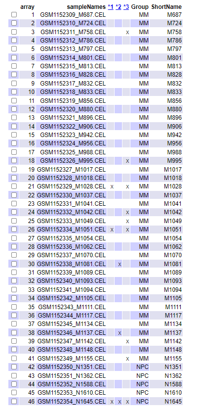

Figure 3.1: Tabla resumen del archivo index.file producido por el paquete *arrayQualityMetrics* para los datos crudos del estudio. 1 = Detección de outlier(s) en el heatmap para las distancias entre arrays ,2 = Detección de outlier(s) en boxplots ,3 = Detección de outlier(s) en MA plots.

```r
knitr::include_graphics("QualityTable.png")
```

Podemos ver que algunas muestras presentan outliers según distintos gráficos diagnósticos, lo cual no es muy sorprendente ya que estamos tratando con datos crudos que necesitaremos normalizar.

A continuación, procedemos a generar una función que nos permitirá ver un PCA plot que muestre si pueden existir diferencias entre los grupos existentes en el conjunto de datos que estemos tratando (en este caso el Raw data):

```r
library(ggplot2)
library(ggrepel)
plotPCA3 <- function (datos, labels, factor, title, scale,colores, size = 1.5, glineas = 0.25) {
  data <- prcomp(t(datos),scale=scale)

  # plot adjustments
  dataDf <- data.frame(data$x)
  Group <- factor
  loads <- round(data$sdev^2/sum(data$sdev^2)*100,1)

  # main plot
  p1 <- ggplot(dataDf,aes(x=PC1, y=PC2)) + theme_classic() +
    geom_hline(yintercept = 0, color = "gray70") +
    geom_vline(xintercept = 0, color = "gray70") +
    geom_point(aes(color = Group), alpha = 0.55, size = 3) +
    coord_cartesian(xlim = c(min(data$x[,1])-5,max(data$x[,1])+5)) +
    scale_fill_discrete(name = "Group")

  # avoiding labels superposition
  p1 + geom_text_repel(aes(y = PC2 + 0.25, label = labels),segment.size = 0.25, size = size) +
    labs(x = c(paste("PC1",loads[1],"%")),y=c(paste("PC2",loads[2],"%"))) +
    ggtitle(paste("Principal Component Analysis para",title,sep=" ")) +
    theme(plot.title = element_text(hjust = 0.5)) +
    scale_color_manual(values=colores)
}
```

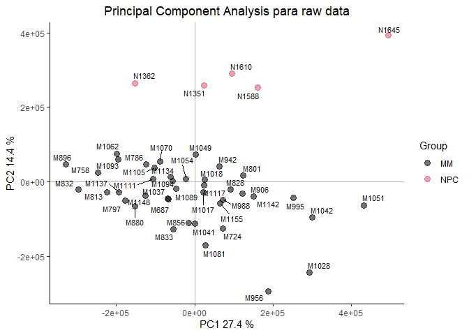

Figure 3.2: Visualización de los dos primeros componentes principales para el raw data

```r
plotPCA3(exprs(rawData), labels = targets$ShortName, factor = targets$Group,
         title="raw data", scale = FALSE, size = 3,
         colores = 1:length(unique(targets$Group)))
```

```r
#Guardamos figura:
jpeg("results/PCA_plot_raw_data.jpeg", res = 200, width = 10, height = 8, units = 'in')
plotPCA3(exprs(rawData), labels = targets$ShortName, factor = targets$Group,
         title="raw data", scale = FALSE, size = 3,
         colores = 1:length(unique(targets$Group)))
dev.off()
```

También podemos ver la distribución de intensidades para nuestro raw data mediante un boxplot:

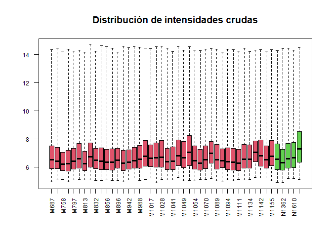

Figure 3.3: Boxplot para intensidades de arrays (Raw Data)

```r
ColoR <- c()
for(i in 2:(length(unique(targets$Group))+1)){
  a <-rep(i,length(targets$Group[targets$Group==unique(targets$Group)[i-1]]))
  ColoR <- c(ColoR,a)
}

boxplot(rawData, cex.axis=0.75, las=2,  which="all",
        col = ColoR,
        main="Distribución de intensidades crudas",names=targets$ShortName)
```

```r
#Guardamos figura:
jpeg("results/boxplot_plot_raw_data.jpeg", res = 200, width = 20, height = 16, units = 'in')
boxplot(rawData, cex.axis=0.75, las=2,  which="all",
        col = ColoR,
        main="Distribución de intensidades crudas",names=targets$ShortName)
dev.off()
```

Vemos que las medianas entre muestras no están muy alineadas, lo que también sugiere la necesidad de normalizar los datos, ya que partimos de la base de que las diferentes condiciones experimentales afectan significativamente a una minoría de genes, lo que en principio debería traducirse en medianas similares entre muestras.

## 3.3 Normalization and quality control of normalized data

Para normalizar los datos crudos de este estudio recurriremos al método RMA (Robust Multi-array Average), el cual realiza para cada sonda una modelización de los valores de intensidad obtenidos en todos los arrays que forman el estudio. Dicha normalización se logra usando la función `rma()` del paquete `affy`, la cual asignamos al objeto `eset_rma`:

```r
eset_rma <- rma(rawData)
```

```
Background correcting
Normalizing
Calculating Expression
```

Una vez hemos realizado la normalización, procedemos a evaluar la calidad de los datos normalizados de manera análoga a como hicimos con el raw data y a guardar los resultados de dicha evaluación en el directorio `QCDir.Norm`:

```r
arrayQualityMetrics(eset_rma, outdir = file.path("./results", "QCDir.Norm"), force=TRUE)
dev.off()
```

La correspondiente tabla resumen del control de calidad de datos normalizados muestra a continuación una mejora general de las muestras:

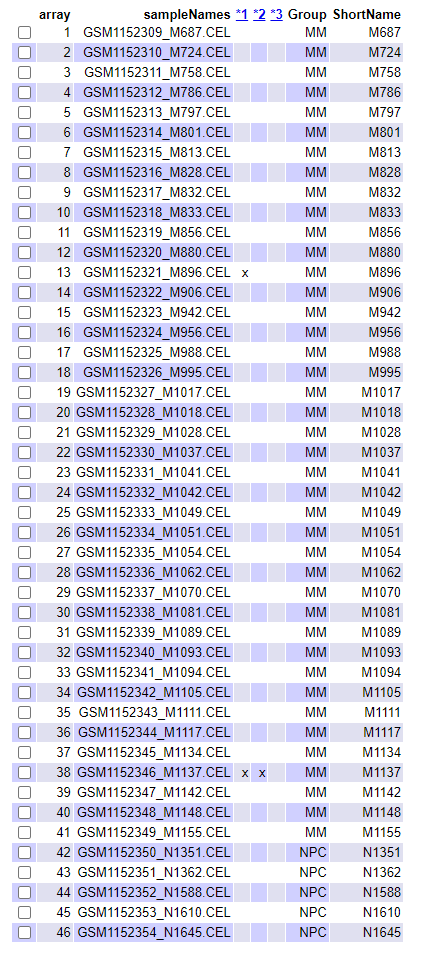

Figure 3.4: Tabla resumen del archivo index.file producido por el paquete arrayQualityMetrics para los datos normalizados del estudio. 1= Detección de outlier(s) en el heatmap para las distancias entre arrays ,2= Detección de outlier(s) en boxplots ,3= Detección de outlier(s) en MA plots.

```r
knitr::include_graphics("QualityTable_Normalized.png")
```

Como se aprecia en esta tabla, aunque el resultado general es mejor que con el raw data, la muestra 38 parece tener outliers según dos de los tres gráficos diagnósticos. Por tanto podríamos considerar eliminar la muestra del estudio. Sin embargo, si miramos el PCA plot de datos normalizados en la figura 3.5, vemos que la muestra que parecía problemática en la tabla resumen de la figura 3.4 no se aleja mucho de las muestras de su mismo grupo. Así mismo, esta muestra presenta una mediana de intensidades similar a las del resto de muestras como vemos en la figura 3.6, luego seguiremos haciendo el análisis de nuestros datos sin excluir esta muestra para no reducir la potencia del análisis.

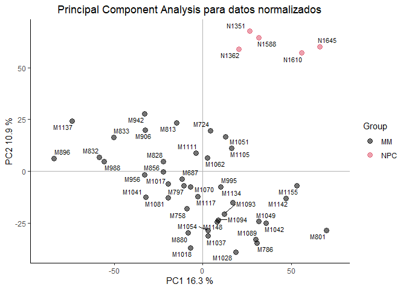

Figure 3.5: Visualización de los dos primeros componentes principales para datos normalizados

```r
pcapl <- plotPCA3(exprs(eset_rma), labels = targets$ShortName, factor = targets$Group,
         title="datos normalizados", scale = FALSE, size = 3,
         colores = 1:length(unique(targets$Group)))

pcapl
```

```r
jpeg("results/PCA_plot_normalized_data.jpeg", res = 200, width = 10, height = 8, units = 'in')
pcapl
dev.off()
```

Como se mencionó anteriormente, podemos ver que la distribución de intensidades de los datos normalizados en la figura 3.6 es bastante homogénea, con lo que usaremos todas las muestras para encontrar genes diferencialmente expresados en los diferentes contrastes y ver en cada caso su significación biológica:

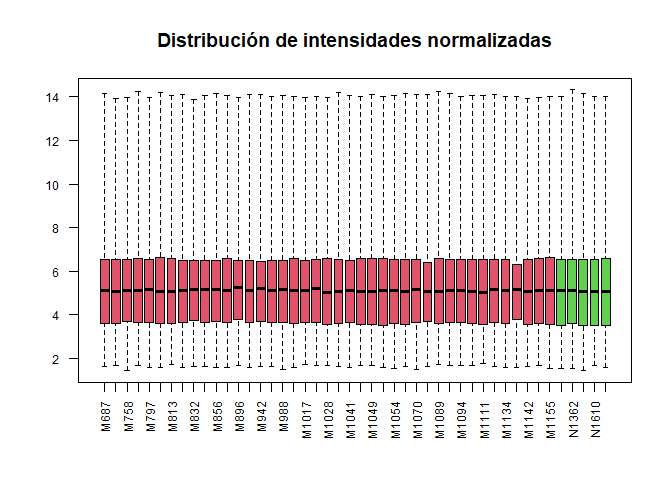

Figure 3.6: Distribución de intensidades para datos normalizados

```r
boxplot(eset_rma, cex.axis=0.75, las=2, col = ColoR,
      main="Distribución de intensidades normalizadas",names=targets$ShortName)
```

```r
#Guardamos figura:
jpeg("results/boxplot_plot_normalized_data.jpeg", res = 200, width = 20, height = 16, units = 'in')
boxplot(eset_rma, cex.axis=0.75, las=2, col = ColoR,
      main="Distribución de intensidades normalizadas",names=targets$ShortName)
dev.off()
```

## 3.4 Batch detection

Puede ser que los microarrays de este estudio se hayan visto afectados por variables no biológicas tales como el uso de reactivos de diferentes lotes, diferentes técnicos llevando a cabo el protocolo, o la más común, la fecha de procesado. El hecho de que en el estudio no se mencione la existencia de bloqueo puede hacer pensar que las muestras se hayan procesado de manera homogénea, bien todas el mismo día, o bien con muestras de cada grupo incluídas en cada día de procesamiento de muestras. Sin embargo, a partir de la función `get.celfile.dates()` aplicada a los archivos .CEL podemos ver que todos los análisis con microarrays no se realizaron el mismo día, sino que se distribuyeron en diferentese fechas de manera no totalmente homogénea, lo cual quizás haya podido introducir variabilidad en los datos obtenidos y produciendo el denominado “*batch effect*”:

```r
library(affyio)
# Fechas de análisis de microarrays:
(Process.date <- get.celfile.dates(paste0("./data/",targets$FileName)))
```

```
 [1] "2009-05-21" "2009-05-21" "2009-05-21" "2009-05-21" "2009-05-21"
 [6] "2009-05-21" "2009-05-21" "2009-05-26" "2009-05-26" "2009-05-26"
[11] "2009-05-26" "2009-05-26" "2009-05-26" "2009-05-26" "2009-05-27"
[16] "2009-05-27" "2009-05-27" "2009-05-27" "2009-05-27" "2009-05-28"
[21] "2009-05-28" "2009-05-28" "2009-05-28" "2009-05-27" "2009-05-28"
[26] "2009-05-28" "2009-05-28" "2009-05-28" "2009-05-29" "2009-05-19"
[31] "2009-05-29" "2009-05-29" "2009-05-29" "2009-05-29" "2009-05-29"
[36] "2009-06-11" "2009-06-11" "2009-05-19" "2009-06-11" "2009-06-11"
[41] "2009-06-11" "2009-02-03" "2009-01-20" "2009-01-20" "2009-02-03"
[46] "2009-01-20"
```

Para analizar un posible “*batch effect*” debido a la fecha de procesado se usará el método Principal Variation Component Analysis (PVCA) mediante la función `pvcaBatchAssess()` del paquete `pvca.` Este método estima la fuente y proporción de variación en dos pasos: el principal component analysis, y el variance component analysis. Usaremos la condición experimental “Group” como referencia para saber en que medida la fecha de procesado (“*batch factor*”) ha podido afectar a los datos obtenidos. Para ello creamos la variable `Process.date` con dichas fechas y las añadimos a `targets`:

```r
# Fechas de procesado añadida a targets
targets$Process.date <-as.character(Process.date)

#Cargamos librería pvca:
library(pvca)
pData(eset_rma) <- targets

#Selección de valor umbral:
pct_threshold <- 0.6

#Factores a analizar:
batch.factors <- c("Group","Process.date")

#Ejecución del análisis:
pvcaObj <- pvcaBatchAssess (eset_rma, batch.factors, pct_threshold)
```

A continuación se muestra un diagrama de barras con una barra para cada fuente de variación y para los correspondientes términos de interacción:

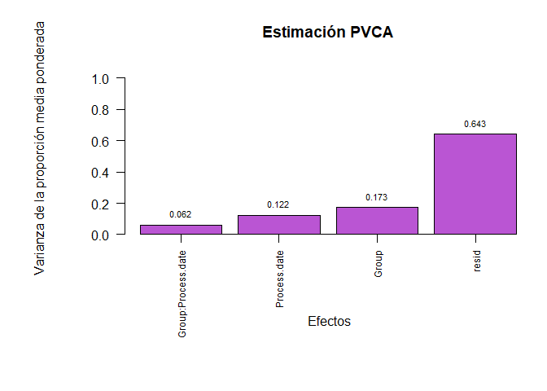

Figure 3.7: Importancia relativa de diferentes factores - Group, process data e interacciones- en la expresión génica

```r
#Ajustamos márgenes del gráfico:
par(mgp=c(5,1,0))
par(mar=c(10, 8, 4, 1))
bp <- barplot(pvcaObj$dat, xlab = "\n Efectos",
              ylab = "Varianza de la proporción media ponderada",
              ylim= c(0,1.1),col = c("mediumorchid"),
              las=2,main="Estimación PVCA")

axis(1, at = bp, labels = pvcaObj$label, cex.axis = 0.75, las=2)
values = pvcaObj$dat
new_values = round(values , 3)
text(bp,pvcaObj$dat,labels = new_values, pos=3, cex = 0.7)
```

Vemos que la principal fuente de variación es residual, y que la variación debida a la fecha de procesado es menor que la variación de Group, luego consideramos que la fecha de procesado no influye en el raw data de este estudio y la ignoramos pues en nuestro análisis.

## 3.5 Detection of genes with highest variability

Los genes diferencialmente expresados son los que mostrarán mayor diferencia entre grupos y por tanto mayor variabilidad general. En el siguiente gráfico podemos ver las desviaciones estándar de los genes ordenadas de menor a mayor, donde los genes con mayor variación y que por tanto podrían estar diferencialmente expresados son aquéllos con desviación estándar mayor a la desviación estándar del 97% de los genes aproximadamente (considerando como valor umbral una desviación estándar > 1).

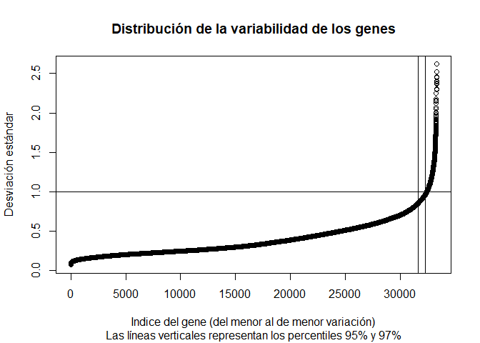

Figure 3.8: Valores de desviación estándar ordenados de menor a mayor para todos los genes a lo largo de todas las muestras

```r
sds <- apply (exprs(eset_rma), 1, sd)

sdsO<- sort(sds)

plot(1:length(sdsO), sdsO, main="Distribución de la variabilidad de los genes",
     sub="Las líneas verticales representan los percentiles 95% y 97%",
     xlab="Indice del gene (del menor al de menor variación)",
     ylab="Desviación estándar")

abline(v=length(sds)*c(0.95,0.97)); abline(h=1)
```

En este caso pues, podríamos tener en mente para futuros resultados que el número de genes diferencialmente expresados podría estar rondando los 998.91 genes para un p-valor < 0.03 teniendo en cuenta todas las comparaciones posibles:

```r
length(sdsO)*0.03
```

```
[1] 998.91
```

## 3.6 Filtering of genes with lowest variability

Con el objetivo de aumentar la potencia de nuestro análisis y por tanto reducir el error tipo II (falsos negativos) conviene reducir el número de genes a los que les aplicamos el contraste para determinar si están diferencialmente expresados. Para ello eliminaremos los genes con menos probabilidad de estar expresados (es decir, aquéllos que tengan menor variabilidad) mediante el uso de la función `nsFilter` del paquete `geneFilter`. También filtraremos sondas sin un identificador del gen asociado, para lo cual debemos usar el paquete de anotación correspondiente al chip usado en este estudio (`hugene10sttranscriptcluster.db`):

```r
library(genefilter)
library(hugene10sttranscriptcluster.db)
annotation(eset_rma) <- "hugene10sttranscriptcluster.db"
filtered <- nsFilter(eset_rma,
                     require.entrez = TRUE, remove.dupEntrez = TRUE,
                     var.filter=TRUE, var.func=IQR, var.cutoff=0.75,
                     filterByQuantile=TRUE, feature.exclude = "^AFFX")
```

La función `nsFilter` devuelve una lista con los valores filtrados y un informe de los resultados del filtraje.

```r
names(filtered)
class(filtered$eset)
```

```r
print(filtered$filter.log) # lista de genes excluídos
```

```
$numDupsRemoved
[1] 993

$numLowVar
[1] 14116

$numRemoved.ENTREZID
[1] 13483
```

```r
eset_filtered <-filtered$eset

# Comparación de número de genes antes y después del filtraje:
dim(eset_rma)
```

```
Features  Samples
   33297       46
```

```r
dim(eset_filtered)
```

```
Features  Samples
    4705       46
```

## 3.7 Saving normalized and filtered data

Los datos normalizados y filtrados son el punto de partida para los siguientes análisis. En caso de necesitar los datos normalizados en el futuro, los guardamos para tenerlos disponibles:

```r
write.csv(exprs(eset_rma), file="./results/normalized.Data.csv")
write.csv(exprs(eset_filtered), file="./results/normalized.Filtered.Data.csv")
save(eset_rma, eset_filtered, file="./results/normalized.Data.Rda")
```

## 3.8 Model estimation to obtain differentially expressed genes

En esta sección se procede a usar los datos normalizados y filtrados para la obtención de genes diferencialmente expresados en determinadas comparaciones (contrastes) entre grupos.

### 3.8.1 Design matrix

Para estimar los contrastes haremos uso del modelo linear para microarrays implementado en el paquete `limma`, el cual requiere que generemos la matriz de diseño asignando cada microarray a uno de los grupos existentes en nuestro estudio. Dicha matriz se puede construir manualmente:

```r
design <- matrix(c(rep(1,41),rep(0,5),rep(0,41),rep(1,5))
                 ,ncol=2,byrow = F)
colnames(design) <- unique(targets$Group)
rownames(design) <- targets$ShortName
design
```

```
      MM NPC
M687   1   0
M724   1   0
M758   1   0
M786   1   0
M797   1   0
M801   1   0
M813   1   0
M828   1   0
M832   1   0
M833   1   0
M856   1   0
M880   1   0
M896   1   0
M906   1   0
M942   1   0
M956   1   0
M988   1   0
M995   1   0
M1017  1   0
M1018  1   0
M1028  1   0
M1037  1   0
M1041  1   0
M1042  1   0
M1049  1   0
M1051  1   0
M1054  1   0
M1062  1   0
M1070  1   0
M1081  1   0
M1089  1   0
M1093  1   0
M1094  1   0
M1105  1   0
M1111  1   0
M1117  1   0
M1134  1   0
M1137  1   0
M1142  1   0
M1148  1   0
M1155  1   0
N1351  0   1
N1362  0   1
N1588  0   1
N1610  0   1
N1645  0   1
```

o bien usando `model.matrix`:

```r
# if (!exists("eset_filtered")) load (file="./results/normalized.Data.Rda")
```

```r
designMat<- model.matrix(~0+Group, pData(eset_filtered))
colnames(designMat) <- sort(unique(targets$Group))
rownames(designMat) <- targets$ShortName
print(designMat)
```

```
      MM NPC
M687   1   0
M724   1   0
M758   1   0
M786   1   0
M797   1   0
M801   1   0
M813   1   0
M828   1   0
M832   1   0
M833   1   0
M856   1   0
M880   1   0
M896   1   0
M906   1   0
M942   1   0
M956   1   0
M988   1   0
M995   1   0
M1017  1   0
M1018  1   0
M1028  1   0
M1037  1   0
M1041  1   0
M1042  1   0
M1049  1   0
M1051  1   0
M1054  1   0
M1062  1   0
M1070  1   0
M1081  1   0
M1089  1   0
M1093  1   0
M1094  1   0
M1105  1   0
M1111  1   0
M1117  1   0
M1134  1   0
M1137  1   0
M1142  1   0
M1148  1   0
M1155  1   0
N1351  0   1
N1362  0   1
N1588  0   1
N1610  0   1
N1645  0   1
attr(,"assign")
[1] 1 1
attr(,"contrasts")
attr(,"contrasts")$Group
[1] "contr.treatment"
```

### 3.8.2 Contrast matrix

El siguiente paso es definir las comparaciones (contrastes) que nos interesen hacer. Es este caso la única comparación que se hace es entre muestras MM y NPC:

```r
library(limma)
cont.matrix <- makeContrasts (Condition = MM - NPC  ,
                              levels=designMat)
print(cont.matrix)
```

```
      Contrasts
Levels Condition
   MM          1
   NPC        -1
```

### 3.8.3 Estimation of the model to select genes

Una vez definida la matriz de diseño y los contrastes, usaremos funciones del paquete `limma` para estimar el modelo (función `lmFit()`) y los contrastes (función `contrasts.fit()`) así como para hacer las pruebas de significación (`eBayes()`) que nos indicarán si cada gen puede considerarse diferencialmente expresado en cada una de las comparaciones que hemos definido en el apartado anterior para el p-valor ajustado y log2FC que consideremos oportuno:

```r
fit<-lmFit(eset_filtered, designMat)
fit.main<-contrasts.fit(fit, cont.matrix)
fit.main<-eBayes(fit.main)
class(fit.main)
```

```
[1] "MArrayLM"
attr(,"package")
[1] "limma"
```

## 3.9 Expressed gene lists order by p-value

A continuación usamos el objeto `fit.main` creado anteriormente para obtener en cada comparación una lista con los genes ordenados de acuerdo a sus p-valores usando la función `topTable()` del paquete `limma`. Los correspondientes p-valores ajustados se calcularán usando el método False Discovery Rate (FDR):

- **Comparación Condition = MM - NPC**:

```r
library(kableExtra)
topTab_Condition <- topTable (fit.main, number=nrow(fit.main), coef="Condition",
                          adjust="fdr",sort.by='p')

knitr::kable(head(topTab_Condition),booktabs = TRUE,
             caption = 'Seis primeros genes expresados diferencialmente para la comparación Condition')
```

Table 3.2: Seis primeros genes expresados diferencialmente para la comparación Condition

|  | logFC | AveExpr | t | P.Value | adj.P.Val | B |
| --- | --- | --- | --- | --- | --- | --- |
| 8043478 | -3.968053 | 5.742265 | -11.368421 | 0 | 0e+00 | 25.08366 |
| 8050875 | -2.413374 | 5.547796 | -9.879981 | 0 | 0e+00 | 20.35412 |
| 8086538 | -2.777854 | 4.097418 | -9.647455 | 0 | 0e+00 | 19.58863 |
| 8020495 | -1.991807 | 5.128737 | -9.054694 | 0 | 0e+00 | 17.60774 |
| 8014551 | -2.079914 | 6.660271 | -8.396182 | 0 | 0e+00 | 15.36274 |
| 8129924 | -2.427357 | 4.881652 | -7.880792 | 0 | 2e-07 | 13.57913 |

$$\\[0.2in]$$

A partir de estas listas podremos obtener los genes diferencialmente expresados en cada caso según los valores de corte que consideremos convenientes para el p-valor ajustado y log2FC.

## 3.10 Gene Annotation

Para anotar las sondas de los microarrays con sus correspondientes nombres de genes, símbolos e identificadores usamos la función `annotatedTopTable` que se muestra a continuación, la cual extrae las columnas pertinentes de nuestra base de datos de anotaciones (`hugene10sttranscriptcluster.db`) y las fusiona con nuestras TopTabs. Para ello, previamente se debe añadir una columna con los PROBEIDs a las TopTabs mostradas en el apartado anterior que servirá de referencia para dicha fusión:

```r
annotatedTopTable <- function(topTab, anotPackage)
{
  topTab <- cbind(PROBEID=rownames(topTab), topTab) # Se añade columna con PROBEIDs
  myProbes <- rownames(topTab)

  # Objeto ChipDb a partir de paquete de anotación:
  thePackage <- eval(parse(text = anotPackage))

  # Selección de columnas de interés del objeto ChipDb:
  geneAnots <- AnnotationDbi::select(thePackage, myProbes, c("SYMBOL", "ENTREZID", "GENENAME"))

  # Fusión de columnas seleccionadas en paso anterior con TopTabs según PROBEID:
  annotatedTopTab<- merge(x=geneAnots, y=topTab, by.x="PROBEID", by.y="PROBEID")
return(annotatedTopTab)
}
```

Una vez preparada la función, la aplicamos a cada una de nuestras tablas para que las sondas queden anotadas y las guardamos como archivos .csv que se podrán consultar separadamente tanto en R como excel o programa similar:

```r
topAnnotated_Condition<- annotatedTopTable(topTab_Condition,
anotPackage="hugene10sttranscriptcluster.db")


index <- which(topAnnotated_Condition$adj.P.Val < 0.05 & abs(topAnnotated_Condition$logFC) >1)
topAnnotated_condition_adj.P.Val0.05_logFC_1 <- topAnnotated_Condition[index,]
topAnnotated_condition_adj.P.Val0.05_logFC_1 <- topAnnotated_condition_adj.P.Val0.05_logFC_1[order(topAnnotated_condition_adj.P.Val0.05_logFC_1$adj.P.Val, decreasing = F),]

#Guardamos tablas
write.csv(topAnnotated_Condition[,-1], file="./results/topAnnotated_Condition.csv", row.names = F, quote = FALSE, sep = '\t')

# write.csv(topAnnotated_condition_adj.P.Val0.05_logFC_1[,-1], file="./results/Annotated_DEGs_Healthy_vs_MM_Log2FC_1_Padj0.05_GSE47552.csv", row.names = FALSE, quote = FALSE, sep = '\t')

# Save table with annotated DEGs as image:
library(ggplot2)
library(gridExtra)
png("C:/Users/Owner/Google Drive/Master Bioinformatica UoC/TFM/Figuras/20 DEGs anotados con menor adj.P.Val en MM cutoff padj 0.05 log2FC 1 GSE47552 dataset.png", res=200,height=140*nrow(head(topAnnotated_condition_adj.P.Val0.05_logFC_1, 20)), width=400*ncol(head(topAnnotated_condition_adj.P.Val0.05_logFC_1, 20)))

p<-tableGrob(head(topAnnotated_condition_adj.P.Val0.05_logFC_1[,-1], 20),rows = NULL)
grid.arrange(p)
dev.off()
```

Comprobamos que la función ha realizado la anotación correctamente mostrando las primeras filas y columnas de la primera comparación:

```r
short1<- head(topAnnotated_Condition[order(topAnnotated_Condition$adj.P.Val),c(1:4,5,9)])
library(kableExtra)
knitr::kable(short1, booktabs = TRUE,row.names = F,
  caption = 'Anotaciones añadidas a "topTable" para la comparación Condition')
```

Table 3.3: Anotaciones añadidas a “topTable” para la comparación Condition

| PROBEID | SYMBOL | ENTREZID | GENENAME | logFC | adj.P.Val |
| --- | --- | --- | --- | --- | --- |
| 8043478 | IGKV1D-8 | 28904 | immunoglobulin kappa variable 1D-8 | -3.968053 | 0e+00 |
| 8050875 | ASXL2 | 55252 | ASXL transcriptional regulator 2 | -2.413374 | 0e+00 |
| 8086538 | LIMD1-AS1 | 644714 | LIMD1 antisense RNA 1 | -2.777854 | 0e+00 |
| 8020495 | CABLES1 | 91768 | Cdk5 and Abl enzyme substrate 1 | -1.991807 | 0e+00 |
| 8014551 | SYNRG | 11276 | synergin gamma | -2.079914 | 0e+00 |
| 7918457 | KCNA3 | 3738 | potassium voltage-gated channel subfamily A member 3 | -2.572281 | 2e-07 |

## 3.11 Visualization of differential expression

### 3.11.1 Volcano plot

Una vez tenemos las tablas anotadas, para cada comparación visualizamos los genes en un volcano plot para ver cuales están expresados diferencialmente de manera más significativa (mayor valor de -log10(p-valor)) y cuales presentan mayor diferencia en nivel de expresión génica entre condiciones experimentales (log2FC) :

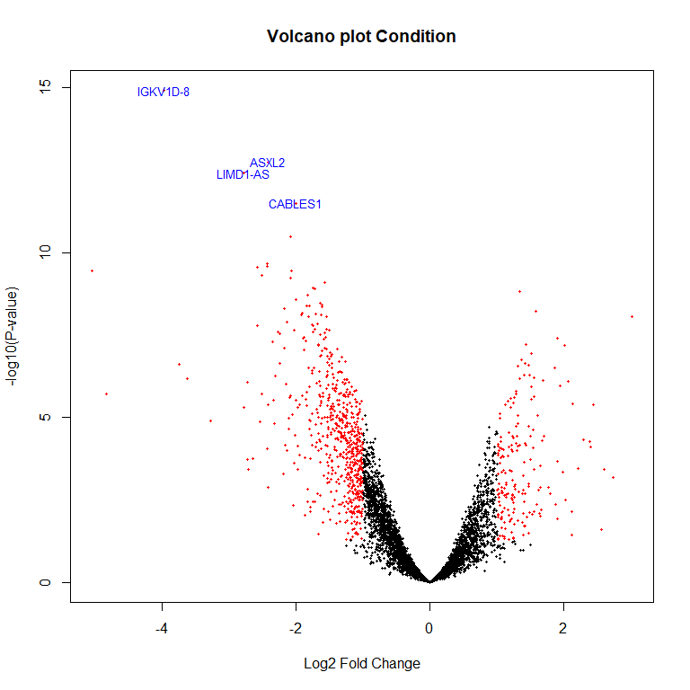

Figure 3.9: Volcano plots para la comparación Condition. Se muestran los nombres para los cuatro genes con menor p valor (primeros cuatro genes en las TopTables).

```r
library(hugene10sttranscriptcluster.db)

for (i in 1:ncol(cont.matrix)){
  geneSymbols <- AnnotationDbi::select(hugene10sttranscriptcluster.db, rownames(fit.main), c("SYMBOL"))
SYMBOLS<- geneSymbols$SYMBOL
volcanoplot(fit.main, coef=1, highlight=4, names=SYMBOLS,
            main=paste("Volcano plot", colnames(cont.matrix)[i]), col = ifelse(fit.main$p.value <0.05 & abs(fit.main$coefficient) >1,'red','black'))

# with(topAnnotated_Condition, plot(logFC, -log10(P.Value), pch=20, main=paste("Volcano plot", colnames(cont.matrix)[i], '\n P.adj < 0.05'),xlab = 'Log2FC'))
# with(subset(topAnnotated_Condition , adj.P.Val>.05 | abs(logFC) < 1), points(logFC, -log10(P.Value), pch=20,col= 'white'))
# with(subset(topAnnotated_Condition, adj.P.Val<.05 & logFC > 1), points(logFC, -log10(P.Value), pch=20, col="green"))
# with(subset(topAnnotated_Condition, adj.P.Val<.05 & logFC < 1), points(logFC, -log10(P.Value), pch=20, col="red"))

}
```

```r
par(mfrow=c(1,1))
```

### 3.11.2 Multiple comparisons and selection of differentially expressed genes

```r
#Selección de genes con FDR < 0.05 y logFC > 1:
res<-decideTests(fit.main, method="separate", adjust.method="fdr", p.value=0.05, lfc=1)

#Tabla resumen:
print(summary(res))
```

```
       Condition
Down         602
NotSig      3937
Up           166
```

Para visualizar simultáneamente genes diferencialmente expresados en distintas comparaciones se podría usar un diagrama tipo Venn. Sin embargo, en este estudio se realiza una única comparación entre muestras (sano vs mieloma multiple), por lo que en este caso no existe posibilidad de comparación múltiple ni de generar el diagrama Venn correspondiente.

### 3.11.3 Heatmaps

Para una visualización intuitiva de genes diferencialmente expresados de una manera similar en nuestro análisis, podemos generar heatmaps para cada comparación, los cuales nos permitirán apreciar en qué medida los genes que hemos seleccionado anteriormente están diferencialmente sobreexpresados o infraexpresados (upregulated o downregulated) para cada condición. Primeramente, creamos el conjunto de datos con las intensidades y símbolos de genes diferencialmente expresados en cada muestra con el mismo criterio de corte usado y lo guardamos como archivo .csv:

```r
res.selected1<-res[res[,1] != 0,] #Genes diferencialmente expresados comparación
comparisons <- c('Condition')
res.selected <- list(res.selected1)
HMdata <- list()

for(i in 1:length(res.selected)){

#PROBEIDs de sondas diferencialmente expresadas:
probesInHeatmap <- rownames(res.selected[[i]])
probesInHeatmap <- topAnnotated_condition_adj.P.Val0.05_logFC_1[order(abs(topAnnotated_condition_adj.P.Val0.05_logFC_1$logFC), decreasing = T),"PROBEID"][1:400]

#Intensidades de genes (sondas) diferencialmente expresados en comparación i:
HMdata[[i]] <- exprs(eset_filtered)[rownames(exprs(eset_filtered)) %in% probesInHeatmap,]

#Se añaden los símbolos de cada gen diferencialmente expresado a HMdata :
geneSymbols <- AnnotationDbi::select(hugene10sttranscriptcluster.db, rownames(HMdata[[i]]), c("SYMBOL"))
SYMBOLS<- geneSymbols$SYMBOL
rownames(HMdata[[i]]) <- SYMBOLS

# Se guarda HMdata como .csv
write.csv(HMdata[[ i]], file = file.path(paste0("./results/data4HeatmapComparison_",comparisons[i],".csv")))
}
```

A continuación, para cada comparación (Condition) visualizaremos los heatmaps para los genes seleccionados en los que FDR < 0.05 and logFC > 1. Además, los genes en filas y las muestras en columnas de cada heatmap se agruparán mediante clustering jerárquico de acuerdo a su similitud en el patrón de expresión. Para ello creamos la funcion `heatmaps` a la que le tendremos que suministrar los argumentos de `HMdata`, `comparación`, `targets$ShortName` y `colores` correspondientes a cada comparación:

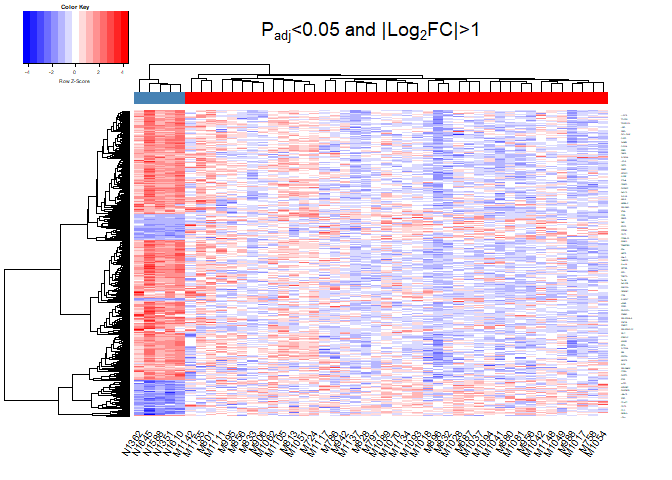

Figure 3.10: Heatmap para datos de expresión génicas agrupados por genes (filas) y columnas (muestras) de acuerdo a su similitud para la comparación Condition

```r
my_palette <- colorRampPalette(c("blue",'white', "red"))
library(gplots)
heatmaps <- function(HMdatos,comparacion,col.nombres, colores){
heatmap.2(HMdatos,
          Rowv = TRUE,
          Colv = TRUE,
          dendrogram = "both",
          main = expression('P'[adj]*'<0.05 and |Log'[2]*'FC|>1'),
          scale = "row",
          col = my_palette,
          sepcolor = "white",
          sepwidth = c(0.05,0.05),
          cexRow = 0.2,
          cexCol = 0.9,
          key = T,
          density.info = "none",
          keysize=1,
          key.par = list(cex=0.3),
          ColSideColors = colores,
          tracecol = NULL,
          srtCol = 55,
          labCol = col.nombres)
}

heatmaps(HMdata[[1]],"Condition",targets$ShortName,c(rep("red", 41),rep("steelblue", 5)))
```

```r
dev.off()
```

```r
heatmaps <- function(HMdatos,comparacion,col.nombres, colores){
heatmap.2(HMdatos,
          Rowv = TRUE,
          Colv = TRUE,
          dendrogram = "both",
          main = " GSE47552 \n padj<0.05 Log2FC > 1 ",
          scale = "row",
          col = my_palette,
          sepcolor = "white",
          sepwidth = c(0.05,0.05),
          cexRow = 0.2,
          cexCol = 0.9,
          key = T,
          density.info = "none",
          lhei = (c(1,8)),
          keysize=1,
          key.par = list(cex=0.3),
          ColSideColors = colores,
          tracecol = NULL,
          srtCol = 55,
          labCol = col.nombres)
}

jpeg(file="results/Heatmap_plot_Healthy_MM_top_200_logFC_DEGs.jpeg", res = 200, width = 30, height = 40, units = 'in')
heatmaps(HMdata[[1]],"Condition",targets$ShortName,c(rep("red", 41),rep("steelblue", 5)))

dev.off()
```

De nuevo vemos aquí la diferencia en expresión entre muestras NPC y MM. El hecho de que veamos bloques de genes sobreexpresados o infraexpresados nos hace pensar que procesos biológicos gobernados al menos en parte por estos bloques de genes quizás estén también afectados significativamente según nuestro análisis, lo cual valoraremos en el siguiente apartado.

## 3.12 Gene set enrichment analysis (GSEA)

```r
listOfTables <- list(Condition = topTab_Condition)
listOfSelected <- list()
for (i in 1:length(listOfTables)){

  # selección the toptable:
  topTab <- listOfTables[[i]]

  # Selección de genes a incluir en el análisis:
  whichGenes <- which(topTab["adj.P.Val"] < 0.05)
  selectedIDs <- rownames(topTab)[whichGenes]

  # conversión de ID a Entrez:
  EntrezIDs<- AnnotationDbi::select(hugene10sttranscriptcluster.db, selectedIDs, c("ENTREZID"))
  EntrezIDs <- EntrezIDs$ENTREZID
  listOfSelected[[i]] <- EntrezIDs
  names(listOfSelected)[i] <- names(listOfTables)[i]
}
sapply(listOfSelected, length) # Tamaño de listas para cada comparación.
```

```
Condition
     1624
```

Mapeamos todos los genes del genoma humano y definiremos como nuestro universo todos los genes que tienen al menos una anotación en Gene Ontology o KEGG:

```r
mapped_genes2GO <- mappedkeys(org.Hs.egGO)
mapped_genes2KEGG <- mappedkeys(org.Hs.egPATH)
mapped_genes <- union(mapped_genes2GO , mapped_genes2KEGG)
```

Procedemos pues al análisis de significación biológica usando `enrichPathway()` y a una posterior visualización de los resultados a través de tablas, barplots y gráficos de red:

A continuación procedemos al análisis de significación biológica usando `enrichPathway()`, para lo cual **establecemos el adj.P.Val de corte a 0.01** para poder ver procesos más enrriquecidos. El objeto resultante también lo usaremos para una posterior visualización de los resultados a través de tablas, barplots y gráficos de red:

```r
library(ReactomePA)

listOfData <- listOfSelected[1]
comparisonsNames <- names(listOfData)
universe <- mapped_genes
enrich.result <- list()

genesIn <- listOfData[[1]]
comparison <- comparisonsNames[1]
enrich.result[[1]] <- enrichPathway(gene = genesIn,
                                 pvalueCutoff = 0.01,
                                 readable = T,
                                 pAdjustMethod = "BH",
                                 organism = "human",
                                 universe = universe)


#Guardado de archivos:

  write.csv(as.data.frame(enrich.result[[1]]),
             file =paste0("./results/","Enriched_Biological_processes",comparison,".csv"),
             row.names = FALSE)
```

```r
knitr::kable(head(enrich.result[[1]]), row.names = F,
                            booktabs = TRUE,
                            caption = paste0("Primeras filas y columnas para los resultados en ",
                                            "ReactomePA.Results.",comparisons[1],".csv"))
```

Table 3.4: Primeras filas y columnas para los resultados en ReactomePA.Results.Condition.csv

| ID | Description | GeneRatio | BgRatio | pvalue | p.adjust | qvalue | geneID | Count |
| --- | --- | --- | --- | --- | --- | --- | --- | --- |
| R-HSA-68886 | M Phase | 71/1011 | 391/10616 | 1e-07 | 0.0000584 | 4.54e-05 | NCAPD2/NUP107/CDC16/AAAS/ANAPC7/PSMB8/SMC1A/MIS12/RB1/BLZF1/…… | 71 |
| R-HSA-69242 | S Phase | 38/1011 | 161/10616 | 1e-07 | 0.0000584 | 4.54e-05 | CABLES1/ORC3/CDC16/CDKN1A/RFC1/ANAPC7/PSMB8/SMC1A/RB1/CDC6/S…… | 38 |
| R-HSA-1428517 | The citric acid (TCA) cycle and respiratory electron transport | 39/1011 | 174/10616 | 3e-07 | 0.0000969 | 7.55e-05 | SUCLA2/COX7C/PDK1/COX5B/COX6C/ETFDH/COX20/SURF1/SDHD/LDHA/ND…… | 39 |
| R-HSA-168254 | Influenza Infection | 36/1011 | 155/10616 | 3e-07 | 0.0000969 | 7.55e-05 | RPS17/RPS19/RPL35/NUP107/RPLP2/RPL24/RPS13/AAAS/RPS5/KPNB1/D…… | 36 |
| R-HSA-168255 | Influenza Life Cycle | 34/1011 | 144/10616 | 4e-07 | 0.0001037 | 8.07e-05 | RPS17/RPS19/RPL35/NUP107/RPLP2/RPL24/RPS13/AAAS/RPS5/KPNB1/D…… | 34 |
| R-HSA-5663205 | Infectious disease | 67/1011 | 382/10616 | 5e-07 | 0.0001037 | 8.07e-05 | RPS17/RPS19/RPL35/NUP107/RPLP2/RPL24/RPS13/AAAS/PSMB8/RPS5/T…… | 67 |

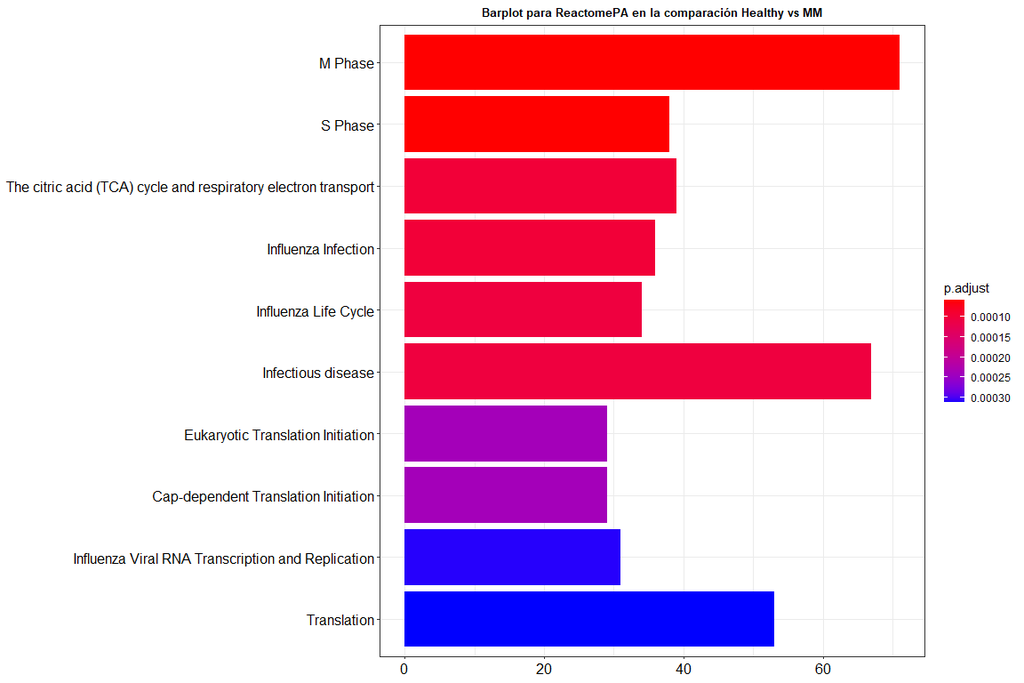

Figure 3.11: Barplot para los procesos biológicos enrriquecidos más significativamente en la comparación Healthy vs MM

```r
library(ggplot2)

p <-  barplot(enrich.result[[1]], font.size = 12,showCategory = 10)

print(p + ggtitle("Barplot para ReactomePA en la comparación Healthy vs MM") + theme(plot.title = element_text(hjust = 0.5,size = 10, face = 'bold')))
```

```r
#Guardamos figura:
jpeg("Results/Enriched_Pathways.jpeg", res = 200, width = 20, height = 16, units = 'in')
print(p + ggtitle("ReactomePA enriched biological processes \n Healthy vs MM") + theme(plot.title = element_text(hjust = 0.5,size = 30, face = 'bold')))
dev.off()
```

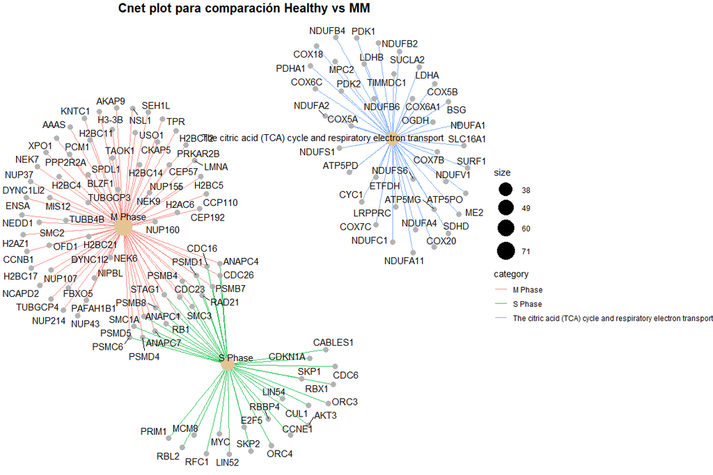

Figure 3.12: Gráfico de red con los procesos biológicos significativamente afectados en la comparación Healthy vs MM

```r
p <- cnetplot(enrich.result[[1]], showCategory = 3, cex_label_category = 3,colorEdge = T)


p <- print(p + ggtitle('Cnet plot para comparación Healthy vs MM') + theme(plot.title = element_text(hjust = 0.5,vjust = 2,face = 'bold',size = 15)))
```

```r
#Guardamos figura:
jpeg(file="Results/Cnet_plot_Healthy_MM.jpeg", res = 300, width = 20, height = 16, units = 'in')
p
dev.off()
```

# References

1. Lopez-Corral L, Corchete LA, Sarasquete ME, Mateos MV, Garcia-Sanz R, Ferminan E, et al. Transcriptome analysis reveals molecular profiles associated with evolving steps of monoclonal gammopathies. Haematologica. 2014;99:1365–72. doi:10.3324/haematol.2013.087809.